[figure not shown]

# Your newsletter

Welcome to your newsletter for **August** . Here are insights based on recording from DECIDErs over the last month and further inspirations.

### A great find!

A visit last month to the highest recording priority area was a visit to Na h-Eileanan Siar and recorded 1 species. One of the species recorded was *Vanessa cardui.*

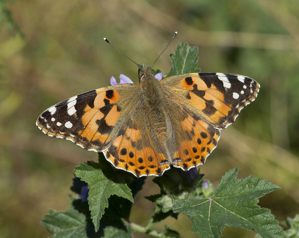

*no rights reserved, uploaded by Anna N Chapman*

[Go to DECIDE](https://decide.ceh.ac.uk/opts/scoremap/map)

### Some inspiration?

Below are some high priority location suggestion, why not go to one of these next time you record?

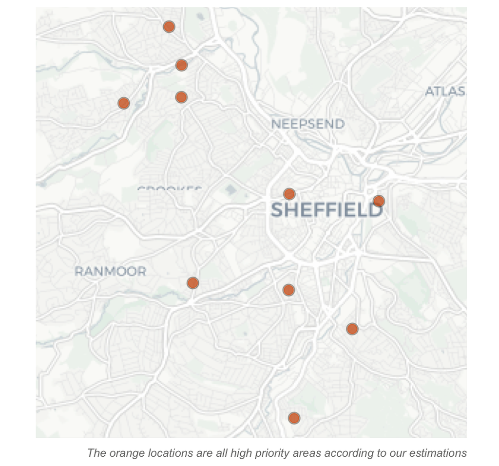

[Go to DECIDE and explore these suggestions?](https://decide.ceh.ac.uk/opts/scoremap/map)

### Community recording near you

The DECIDE comunity has been very active this month. See where your records fall within them:

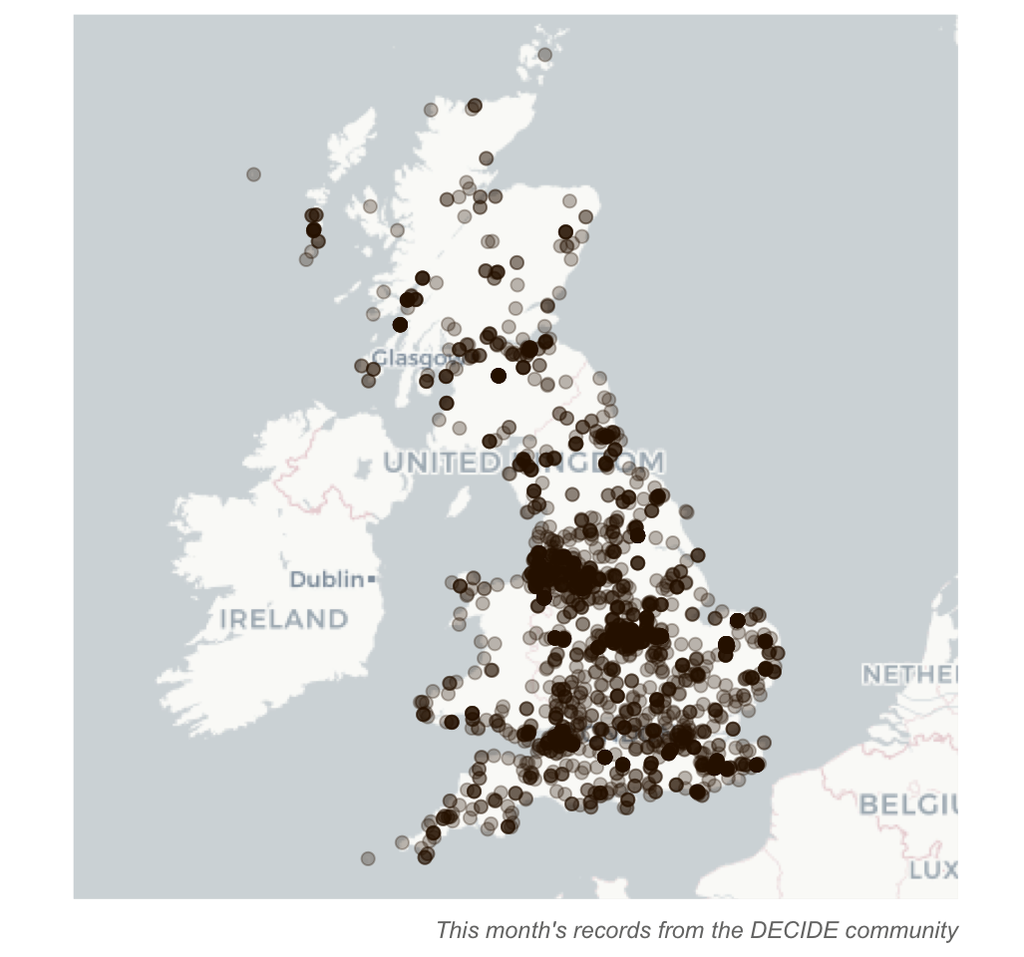

Why not find some gaps in your area using the DECIDE tool?

[Go to DECIDE](https://decide.ceh.ac.uk/opts/scoremap/map)

### DECIDE score over the months?

High DECIDE scores indicate records from high priority areas. See how the community stacks up scores in August

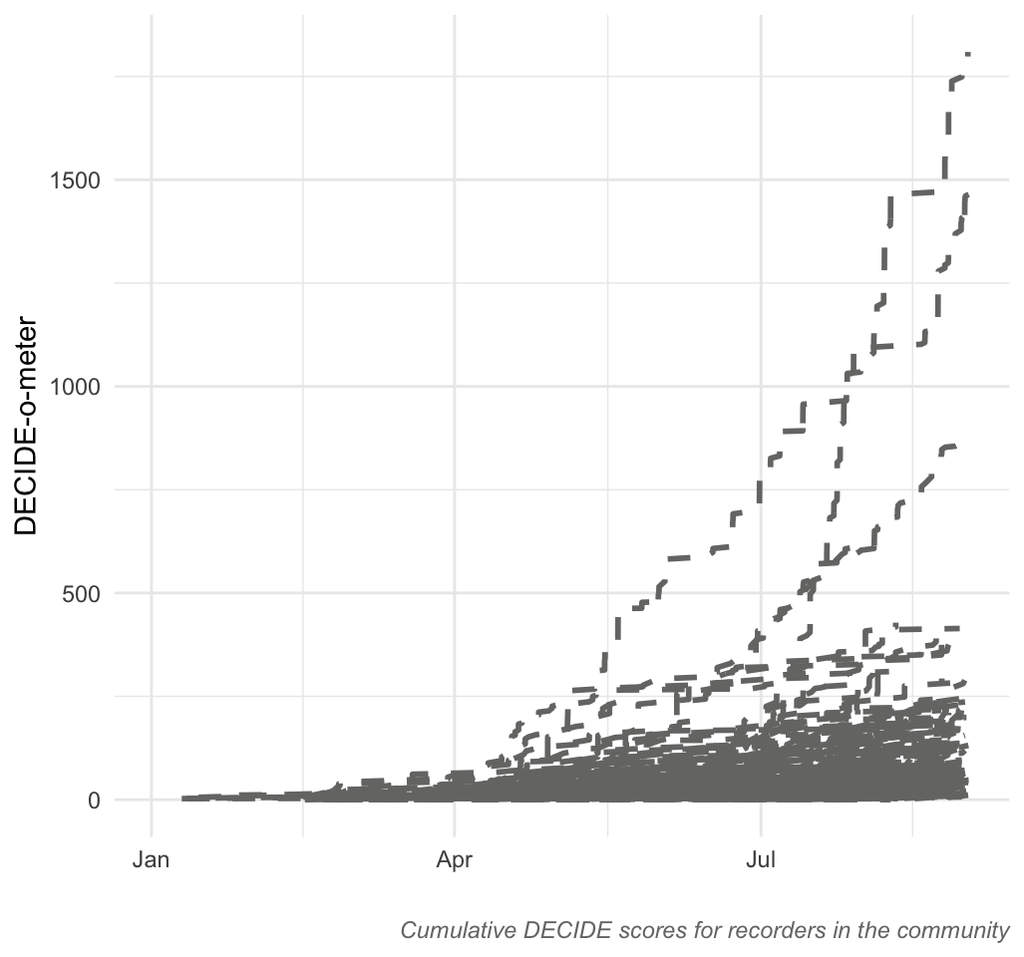

Why not find areas with high priority scores using the DECIDE tool?

[Go to DECIDE](https://decide.ceh.ac.uk/opts/scoremap/map)

Don't want to receive these emails any more? Unsubscribe from the DECIDE personalised newsletter